# Loan Data Exploration

## by Karim Henry

## Preliminary Wrangling

> This document explores a dataset containing amount, status , interest rate and other attributes for approximately 114,000 loans.

> Interest rate refers to the annual cost of a loan to a borrower and is expressed as a percentage APR is the annual cost of a loan to a borrower — including fees. Like an interest rate, the APR is expressed as a percentage. Unlike an interest rate, however, it includes other charges or fees such as mortgage insurance, most closing costs, discount points and loan origination fees. Why the difference? The APR is intended to give you more information about what you’re really paying. The Federal Truth in Lending Act requires that every consumer loan agreement disclose the APR. Since all lenders must follow the same rules to ensure the accuracy of the APR, borrowers can use the APR as a good basis for comparing certain costs of loans.

> In prosper score, we indicate customer riskwith range from 1 to 11 with 1 being the worst, highest risk.

> In CreditGrade, AA indicates lower risk while HR indicates highest risk.

### Counting Missing Data

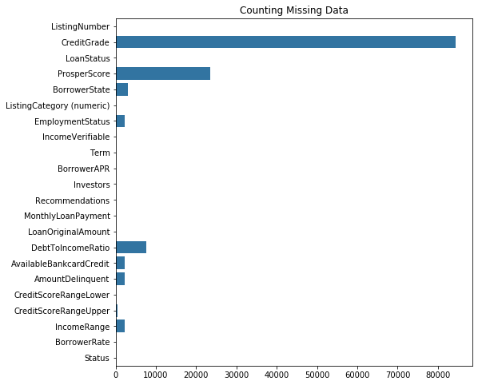

```python
plt.figure(figsize=[8,8])
na_counts = red_df.isna().sum()
base_color = sb.color_palette()[0]
sb.barplot(y=na_counts.index.values, x=na_counts, color = base_color);
plt.title('Counting Missing Data');
```

> We must take into account that using credit grade or prosper score can be not representative for the whole dataset due to large number of missing data.

### What is the structure of your dataset?

There are 112,990 loans in the dataaset with 20 features ( listing number, Credit Grade,Loan Status, Prosper Score, Listing Category (numeric), Employment Status,Term, Borrower APR, Investors, Recommendations, Monthly Loan Payment, Loan Original Amount, Debt To Income Ratio, Available Bank card Credit, Amount Delinquent, Credit Score Range Lower, Credit Score Range Upper, Income Range, Income Verifiable,borrower interest rate). Part of data is numerical as borrower interest rate and monthly loan payment and part of data is presented as ordered level:

Prosper score : 1 (highest risk) -----> 11 (lowest risk)

Credit Grade : AA (loweST risk), B, C, D, E, HR (highest risk)

Income Range : 0 ------> 100000+

### What is/are the main feature(s) of interest in your dataset?

We are dealing with 20 features whereby we will explore which of these features are impacting loan status which could be helpful in predicting future behavior of investors. Also, we will investigate the factors affecting interest rate and APR. Finally, we will try to understand whether there are differences between loans depending on their amounts.

### What features in the dataset do you think will help support your investigation into your feature(s) of interest?

I expect that debt to income ratio along with credit grade & score will have greatest impact on loan status.Also, prosper score and credit grade when combined with loan amount could affect interest rate whereby as amount increase, interest rate decrease. Investigating of other features could lead to different results.

## Univariate Exploration

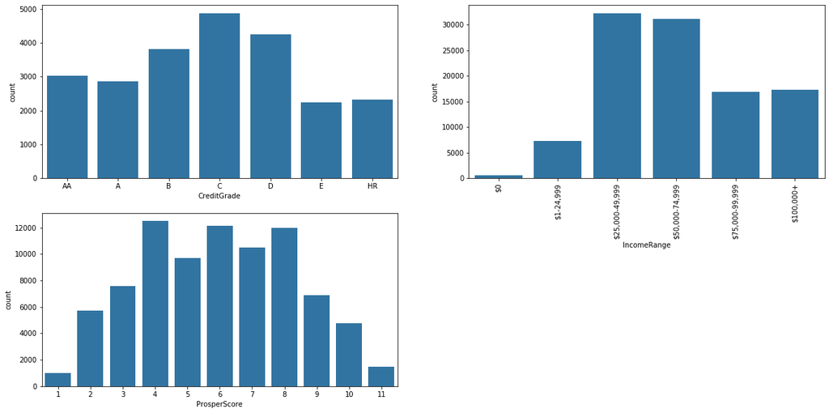

```python
plt.figure(figsize=[20,10])
plt.subplot(2,2,1)
base_color = sb.color_palette()[0]
sb.countplot(data = red_df, x = 'CreditGrade', color = base_color);
plt.subplot(2,2,2)
sb.countplot(data = red_df, x = 'IncomeRange', color = base_color);
plt.xticks(rotation=90);
plt.subplot(2,2,3)
sb.countplot(data = red_df, x = 'ProsperScore', color = base_color);
```

> The above figures implies that majority of clients' income range is between 25k and 75k. Regarding the credit grade, most clients are receiving grade C implying moderate risk factor. Also, prosper score lies between 4 and 8 with three peaks at 4,6,8. However, we must be careful that credit grade is the credit rating that was assigned at the time the listing went live and is applicable for listings pre-2009 period and will only be populated for those listings so it may be not representative for the whole dataset.

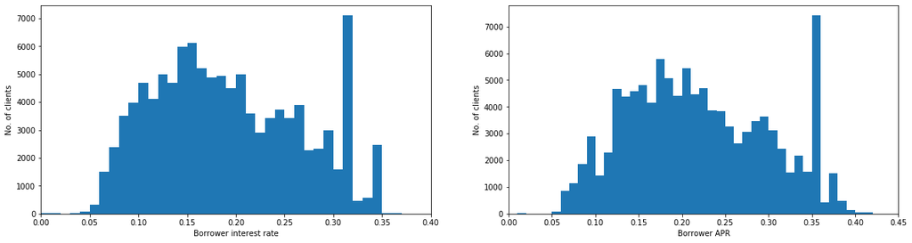

```python
plt.figure(figsize=[20,5])
plt.subplot(1,2,1)
bins=np.arange(0,red_df.BorrowerRate.max()+0.01,0.01);
plt.hist(data=red_df,x='BorrowerRate',bins=bins);
plt.xlabel('Borrower interest rate');
plt.ylabel('No. of clients');
plt.xlim(0,0.4);
plt.subplot(1,2,2)
bins=np.arange(0,red_df.BorrowerAPR.max()+0.01,0.01);
plt.hist(data=red_df,x='BorrowerAPR',bins=bins);
plt.xlabel('Borrower APR');
plt.ylabel('No. of clients');
plt.xlim(0,0.45);
```

> As we have noted the difference between interest rate and APR, the data in APR is shifted to the right to somehow higher values. The 2 figures show there is a peak at interest rate beween 0.12 up to 0.18 with an abrupt increase in interest rate at 0.32, maybe it is attributed to a certain condition or loan amount. Investigating interest along with other data will reveal somehow a better understanding.

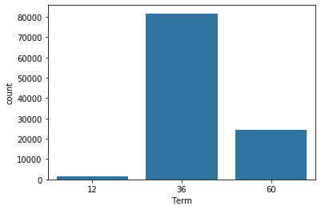

```python
base_color = sb.color_palette()[0]
sb.countplot(data=red_df,x='Term',color=base_color);
```

> Majority of loans of 36 months. Maybe it is attributed to a certain purpose.Deeper investigation with other factors would help us understand.

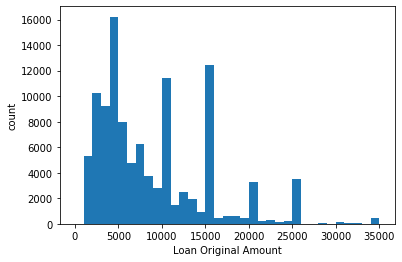

```python
bins=np.arange(0,red_df.LoanOriginalAmount.max()+1000,1000);
plt.hist(data=red_df,x='LoanOriginalAmount',bins=bins);
plt.xlabel('Loan Original Amount');
plt.ylabel('count');
```

> Loan original amount is somehow skewed to the right so we will be applying logarithmic transformation.

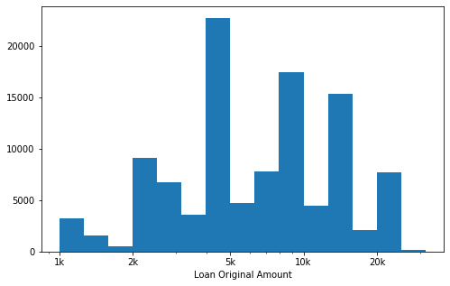

```python
bins = 10 ** np.arange(3,4.5+0.1,0.1 )

plt.figure(figsize=[8, 5])
plt.hist(data = red_df, x = 'LoanOriginalAmount', bins = bins)
plt.xscale('log')
plt.xticks([ 1e3, 2e3, 5e3, 1e4, 2e4], ['1k', '2k', '5k', '10k', '20k'])
plt.xlabel('Loan Original Amount')
plt.show()
```

> Transformation adjusts skewness but we are seeing increase in amount reaching a peak at approximately 4k then decrease. The ups and downs may be attributed to the fact that more clients prefer amounts of 1k and its multiples.

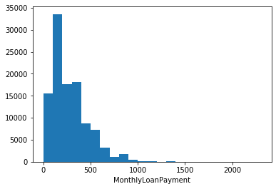

```python
bins=np.arange(0,red_df.MonthlyLoanPayment.max()+100,100);
plt.hist(data=red_df,x='MonthlyLoanPayment',bins=bins);
plt.xlabel('MonthlyLoanPayment');
```

> As before,we will be applying logarithmic transformation as monthly payment is somehow long-tailed.

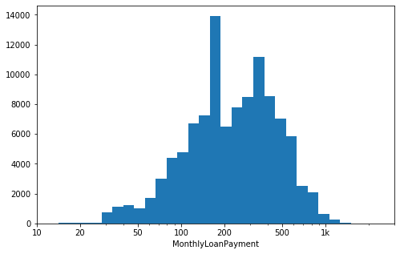

```python
bins = 10 ** np.arange(-2,3.3+0.075,0.075 )

plt.figure(figsize=[8, 5])
plt.hist(data = red_df, x = 'MonthlyLoanPayment', bins = bins)
plt.xscale('log')
plt.xlim(10,3000)
plt.xticks([ 1e1,2e1 ,5e1, 1e2,2e2,5e2, 1e3], ['10','20','50', '100','200','500', '1k'])
plt.xlabel('MonthlyLoanPayment')
plt.show()
```

> Log tranformation produces 2 peaks, one between 140 to 160 and another one between 300 and 400.

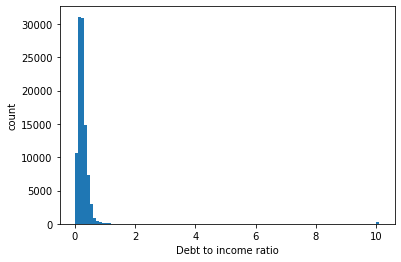

```python
bins=np.arange(0,red_df.DebtToIncomeRatio.max()+0.1,0.1);
plt.hist(data = red_df, x = 'DebtToIncomeRatio', bins = bins);
plt.xlabel('Debt to income ratio');
plt.ylabel('count');
```

> Long tailed curve with values reaching 10 so we will be applying log transformation.

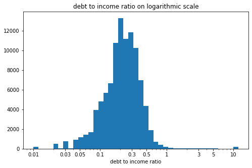

```python
bins = 10 ** np.arange(-2,1+0.075,0.075 )

plt.figure(figsize=[8, 5])
plt.hist(data = red_df, x = 'DebtToIncomeRatio', bins = bins)
plt.xscale('log')
#plt.xlim(10,3000)
plt.xticks([ 1e-2,3e-2 ,5e-2, 1e-1,3e-1,5e-1, 1e0,3e0,5e0,1e1], ['0.01','0.03','0.05', '0.1','0.3','0.5', '1','3','5','10'])
plt.xlabel('debt to income ratio')
plt.title('debt to income ratio on logarithmic scale')
plt.show()
```

> log transormation produces a uniform model with peak at approximately 0.2.

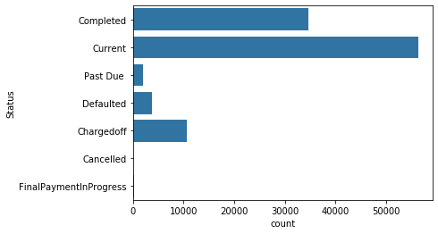

```python
sb.countplot(data=red_df,y='Status',color=base_color);
```

> The above figures state that the majority of loans are current loans or completed loans. A small portion has passed the due date. Loan cancellation is the least loan status with approximately 5.

### Discuss the distribution(s) of your variable(s) of interest. Were there any unusual points? Did you need to perform any transformations?

> Loan amounts took on higher values at 1k and its multiples but in general these higher values keep increaing from 1k up to 5k then decreases to 20k on log scale. we have also applied logarithmic transformation to loan monthly payment which produces a bimodel. Debt to income ratio reflected outliers reaching very high values up 10. On log scale, it produced a uniform model with peak at approximately 0.2.

### Of the features you investigated, were there any unusual distributions? Did you perform any operations on the data to tidy, adjust, or change the form of the data? If so, why did you do this?

> Debt to income ratio reflected outliers reaching very high values up 10. On log scale, it produced a uniform model with peak at approximately 0.2.

## Bivariate Exploration

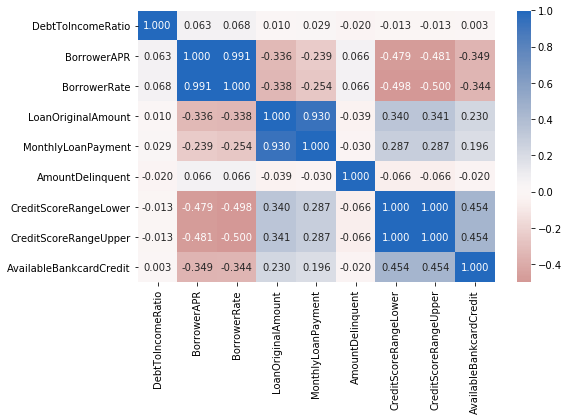

```python
plt.figure(figsize = [8, 5])
sb.heatmap(red_df[corr_col].corr(), annot = True, fmt = '.3f',cmap = 'vlag_r', center = 0)
plt.show();
```

> this grid shows pearson coef for numeric variables

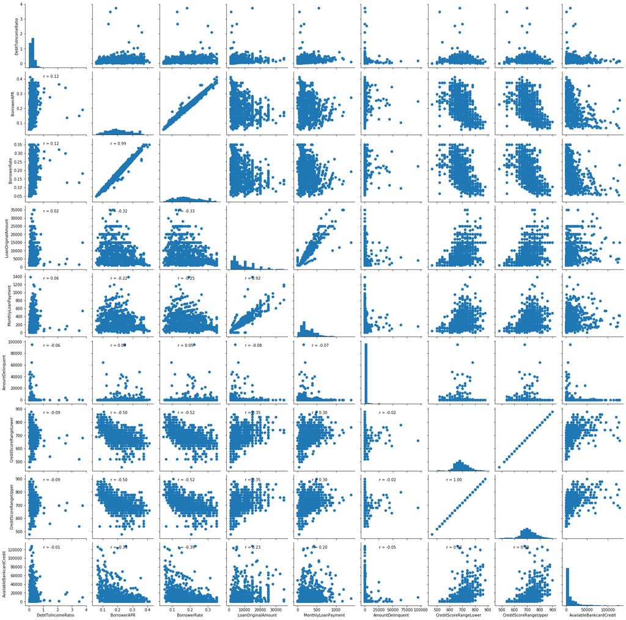

```python
from scipy import stats

def corrfunc(x, y, **kws):
    r, _ = stats.pearsonr(x, y)
    ax = plt.gca()
    ax.annotate("r = {:.2f}".format(r),xy=(.3, .9), xycoords=ax.transAxes)
red_sample=red_df_debtto_inrat.sample(n=1000,axis=0,replace=False)
g = sb.PairGrid(data = red_sample, vars = corr_col);
g = g.map_diag(plt.hist, bins = 20);
g.map_offdiag(plt.scatter);
g.map_lower(corrfunc);
```

> Taking a sample help reduce rendering time, simultaneously, gives clearer plots. This is a scatter grid of 1000 samples.

As expected monthly payment is highly correlated with loan original amount. Upper and lower credit scores are strongly correlated with each other. Relation between credit score and interest rate and loan amount needs further investigation. Higher available credit is associated with lower interest rate. Interest rate is strongly correlated with borrower APR.

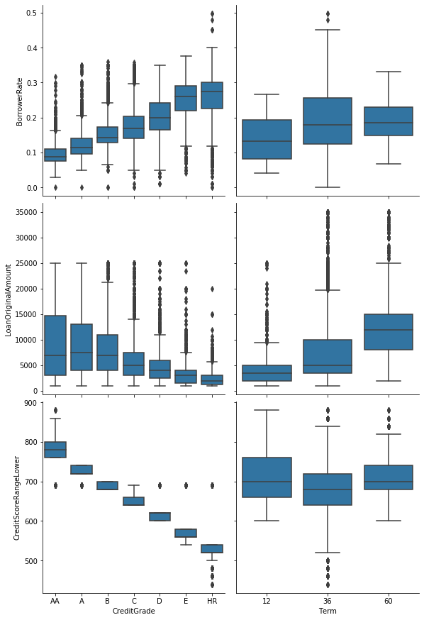

```python
def boxgrid(x, y, **kwargs):
    base_color = sb.color_palette()[0]
    sb.boxplot(x, y, color = base_color)

g = sb.PairGrid(data = red_df_debtto_inrat, y_vars = ['BorrowerRate', 'LoanOriginalAmount','CreditScoreRangeLower'],
                x_vars = ['CreditGrade','Term'],size = 4, aspect = 1,dropna=True)
g.map(boxgrid)
plt.show();
```

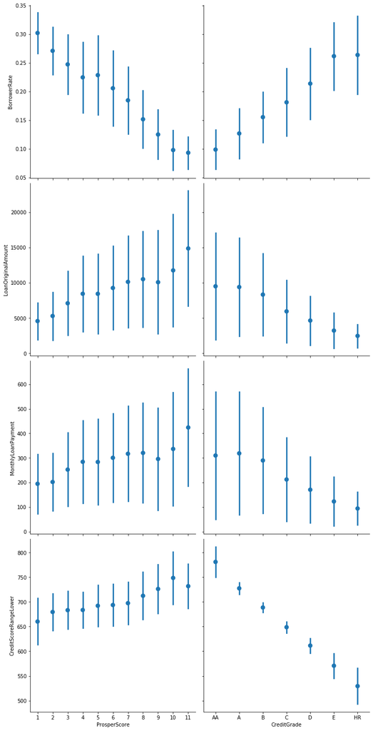

```python
def pointgrid(x, y, **kwargs):
    base_color = sb.color_palette()[0]
    sb.pointplot(x, y, color = base_color,ci='sd',linestyles='')

g = sb.PairGrid(data = red_df, y_vars = ['BorrowerRate', 'LoanOriginalAmount','MonthlyLoanPayment','CreditScoreRangeLower'],
                x_vars = ['ProsperScore','CreditGrade'],size = 5, aspect = 1,dropna=True)
g.map(pointgrid)
plt.show();
```

> It is obvious from the above plots that average interest rate decreases as risk decrease whereby lowest interest rate is associated with minimum risk.As expected,the average credit score is minimum at highest risk. Also, higher income ranges are associated with lower interest rate and somehow higher credit score. Concerning loan original amount, it increases at longer loan periods.Also greater loan amounts is achieved at higher income rates. Also, Loan original amount is greater for lower risk grades.

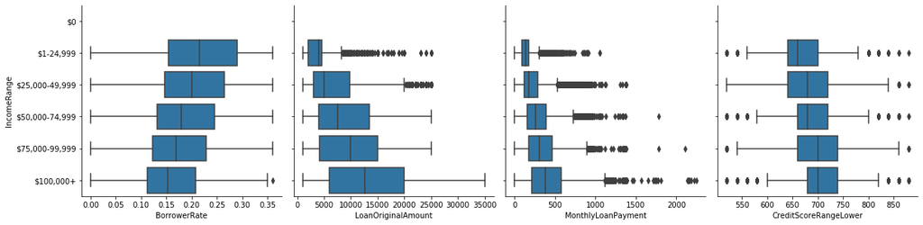

```python
def boxgrid(x, y, **kwargs):
    base_color = sb.color_palette()[0]
    sb.boxplot(x, y, color = base_color)

g = sb.PairGrid(data = red_df_debtto_inrat, x_vars = ['BorrowerRate', 'LoanOriginalAmount','MonthlyLoanPayment','CreditScoreRangeLower'],
                y_vars = ['IncomeRange'],size = 4, aspect = 1,dropna=True)
g.map(boxgrid)
```

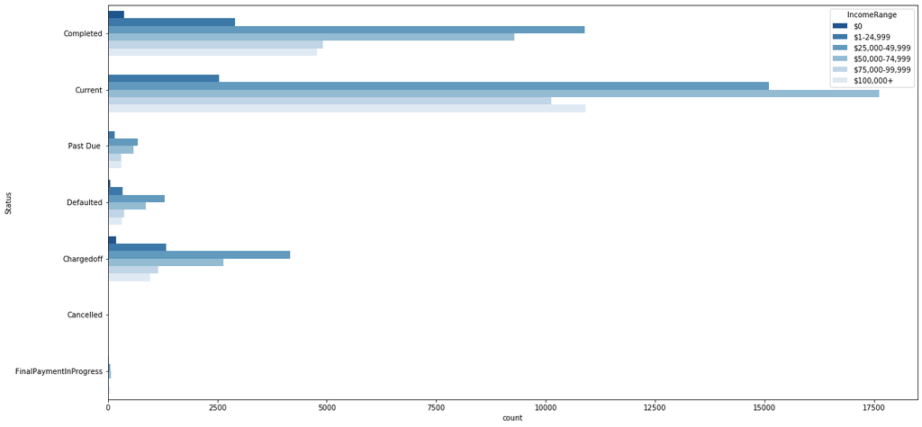

```python
red_df_status1=red_df.query("LoanStatus in ['Current','Completed','Chargedoff','Defaulted']")
red_df_status2=red_df.query("LoanStatus in ['FinalPaymentInProgress','Past Due (1-15 days)','Past Due (16-30 days)','Past Due (31-60 days)','Past Due (61-90 days)','Past Due (91-120 days)','Past Due (>120 days)','Cancelled']");

plt.figure(figsize=[20,10])

sb.countplot(data = red_df, y = 'Status', hue = 'IncomeRange',palette ='Blues_r');
```

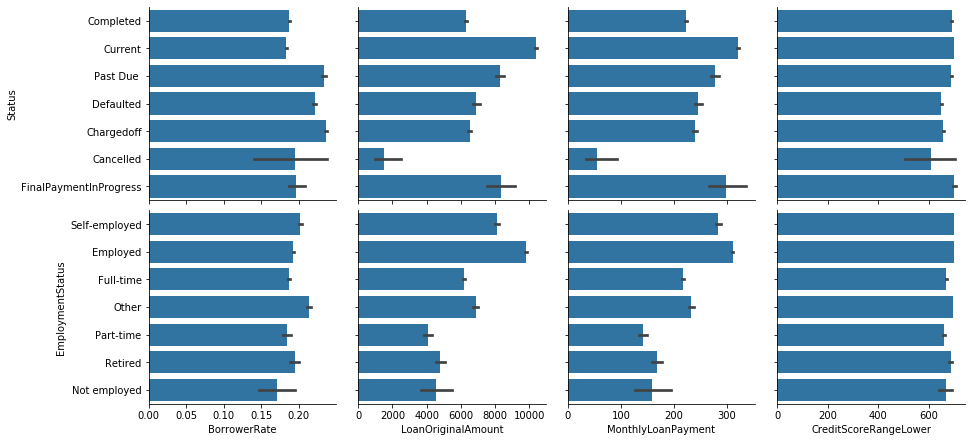

```python
def bargrid(x, y, **kwargs):
    base_color = sb.color_palette()[0]
    sb.barplot(x, y, color = base_color)
g = sb.PairGrid(data = red_df, x_vars = ['BorrowerRate', 'LoanOriginalAmount','MonthlyLoanPayment','CreditScoreRangeLower'],
            y_vars = ['Status','EmploymentStatus'],size = 3, aspect = 1,dropna=True)
g.map(bargrid);
```

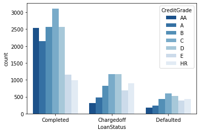

```python
sb.countplot(data = red_df_status1, x = 'LoanStatus', hue = 'CreditGrade',palette ='Blues_r',order=['Completed','Chargedoff','Defaulted'])
```

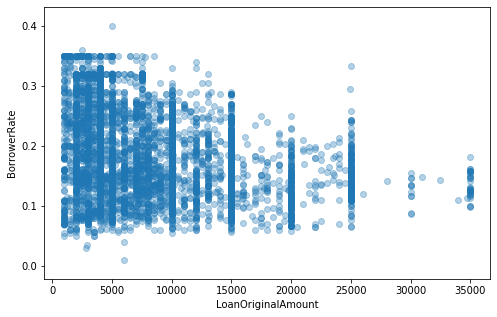

```python
plt.figure(figsize = [8, 5])
plt.scatter(data = red_df.sample(5000,replace=False), y = 'BorrowerRate', x = 'LoanOriginalAmount', alpha = 1/3)
plt.xlabel('LoanOriginalAmount')
plt.ylabel('BorrowerRate')
plt.show()
```

> The above scatter can hardly be used to correlate the 2 variables but it suggests that higher loans are having somehow lower interest rate. Loan Period term could help better emphasize this relation.

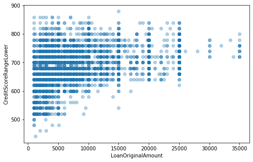

```python
plt.figure(figsize = [8, 5])
plt.scatter(data = red_df.sample(5000,replace=False,random_state=26), y = 'CreditScoreRangeLower', x = 'LoanOriginalAmount', alpha = 1/3)
plt.xlabel('LoanOriginalAmount')
plt.ylabel('CreditScoreRangeLower')
plt.show()
```

> As expected, greater loan amounts take place at higher credit score.

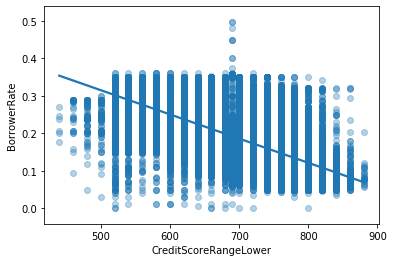

```python
sb.regplot(data=red_df, x='CreditScoreRangeLower',y='BorrowerRate',
           scatter_kws={'alpha':1/3});
```

> This plot reflects that interest rate somehow decreases as credit score especially after a threshold score of approximately 800 whereby cloud of points decrease.

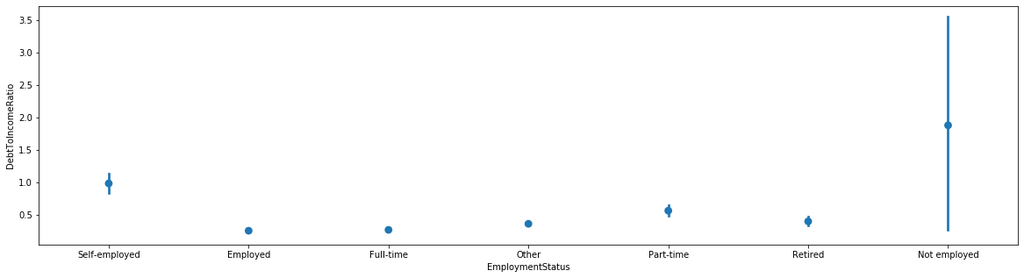

```python
plt.figure(figsize=[20,5])
sb.pointplot(data = red_df, x = 'EmploymentStatus', y = 'DebtToIncomeRatio', linestyles = '');
```

> Debt to income rate reaches high values for non employed people hitting values of 3.5

### Talk about some of the relationships you observed in this part of the investigation. How did the feature(s) of interest vary with other features in the dataset?

> our predictions concerning that interset rate would increase with time wasn't achieved as we can see through the box plot whereby average interest rate increased from 12 to 36 months but then remained within same range. Interest rate is somehow attributed to credit score. I think we will be introduced to new results with multivariable visualizations. The great number of features requires deeper investigations to be able to come with reliable results.Larger loan amounts over a certain threshold are attributed to employed clients.

### Did you observe any interesting relationships between the other features (not the main feature(s) of interest)?

> I think we will be introduced to new results with multivariable visualizations. The great number of features requires deeper investigations to be able to come with reliable results.

## Multivariate Exploration

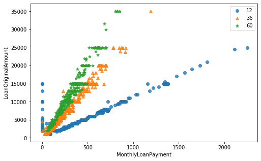

```python
plt.figure(figsize=[8,5])
ttype_marker=[[12,'o'],[36,'^'],[60,'*']]
for ttype,marker in ttype_marker:
    plot_data=red_df.loc[red_df['Term']==ttype]
    sb.regplot(data=plot_data.sample(500,replace=False),x='MonthlyLoanPayment',y='LoanOriginalAmount'
                ,fit_reg=False,marker=marker)

plt.legend(['12','36','60']);
```

> The above figure illustrates relation between monthly payment and loan amount in each of the loan periods whether 12,36 or 60 months. Monthly Payment is strongly correlated with original loan payment at 3 levels of loan period. for same loan amount, higher value of monthly payment is seen for shorter period. The increase in monthly payment for same loan amount from 60 to 36 month is small compared to that between 36 and 12 month.

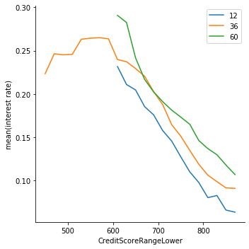

```python
def mean_poly(x, y, bins = 10, **kwargs):

    if type(bins) == int:
        bins = np.linspace(x.min(), x.max(), bins+1)
    bin_centers = (bin_edges[1:] + bin_edges[:-1]) / 2


    data_bins = pd.cut(x, bins, right = False,
                       include_lowest = True)
    means = y.groupby(data_bins).mean()


    plt.errorbar(x = bin_centers, y = means, **kwargs)
bin_edges = np.arange(440, red_df['CreditScoreRangeLower'].max()+20, 20)
g = sb.FacetGrid(data = red_df, hue = 'Term', size = 5)
g.map(mean_poly, "CreditScoreRangeLower", "BorrowerRate", bins = bin_edges)
g.set_ylabels('mean(interest rate)')
plt.legend();
```

> The interst rate depends on credit score and on loan period whereby interest rate decrease from nearly 0.29 at score of 620 to about 0.12 at score of 850 for 60 months also interest rate is at lower levels for shorter loan periods at the smae scores whereby we can see, for instance, interest rate decreasing from 0.15 to 0.11 ending with values below 0.10 as period declines from 60 to 36 ending with 12 months.

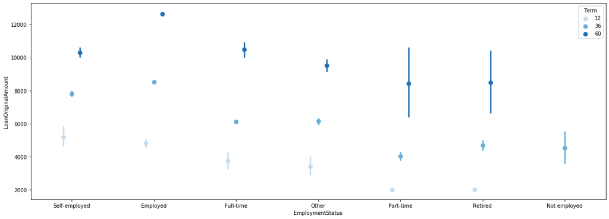

```python
plt.figure(figsize = [20,7])

sb.pointplot(data = red_df, x = 'EmploymentStatus', y = 'LoanOriginalAmount', hue = 'Term',palette = 'Blues',
             linestyles = '', dodge = 0.2)

plt.show();
```

> We can see that non employed people are not allowed long loan periods of 60 months, with smaller loan amounts with a maximum of 6000 dollars.

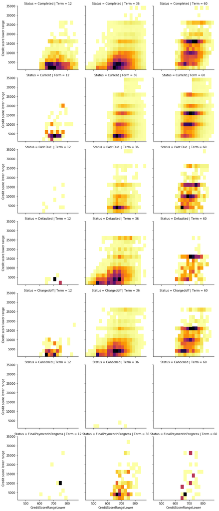

```python
g = sb.FacetGrid(data = red_df, row = 'Status',col='Term' , size = 3.5)
g.map(hist2dgrid, 'CreditScoreRangeLower', 'LoanOriginalAmount', color = 'inferno_r')

g.set_ylabels('Credit score lower range')

plt.show()
```

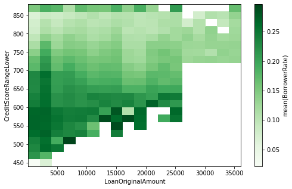

```python
plt.figure(figsize=[8,5])
xbin_edges = np.arange(100, 37000, 2000)
ybin_edges = np.arange(440,880+20, 20)

xbin_idxs = pd.cut(red_df['LoanOriginalAmount'], xbin_edges, right = True,include_lowest = True, labels = False).astype(int)

ybin_idxs = pd.cut(red_df['CreditScoreRangeLower'], ybin_edges, right = True,include_lowest = True, labels = False).astype(int)

pts_per_bin = red_df.groupby([xbin_idxs, ybin_idxs]).size()
pts_per_bin = pts_per_bin.reset_index()
pts_per_bin = pts_per_bin.pivot(index = 'LoanOriginalAmount', columns = 'CreditScoreRangeLower').values

z_wts = red_df['BorrowerRate'] / pts_per_bin[xbin_idxs, ybin_idxs]

plt.hist2d(data = red_df, x = 'LoanOriginalAmount', y = 'CreditScoreRangeLower', weights = z_wts,
           bins = [xbin_edges, ybin_edges], cmap = 'Greens', cmin = 0.01);
plt.xlabel('LoanOriginalAmount')
plt.ylabel('CreditScoreRangeLower');
plt.colorbar(label = 'mean(BorrowerRate)');
```

## Thank you Hope you enjoyed